# Graph Gallery

Dave Lorenz

14 September, 2015

These examples demonstrate selected high-level plotting functions in the smwrGraphs package that are not covered in other vignettes of demos. **NOTE:** to use any of these functions, you must first call a function to set up the graphics environment like `setPage` or `setPDF`.

```r
# Load the smwrGraphs package
library(smwrGraphs)
# Load the smwrData package and some data
library(smwrData)
data(IonBalance)
data(MiscGW)
# Transform the data. These examples will ignore potassium, fluoride,
# nitrate, and carbonate.
PD <- transform(MiscGW, Ca.meq = conc2meq(Calcium, "calcium"),
  Mg.meq = conc2meq(Magnesium, "magnesium"),
  Na.meq = conc2meq(Sodium, "sodium"),
  Cl.meq = conc2meq(Chloride, "chloride"),
  SO4.meq = conc2meq(Sulfate, "sulfate"),
  HCO3.meq = conc2meq(Bicarbonate, "bicarb")) # abbreviations allowed
data(MC11_1993)
```

# Graph with Error Bars

The `xyPlot` function plots paired x- and y-coordinate data. As of version 1.0, there are methods for factor and numeric x-coordinate data and numeric y-coordinate data. This example plots factor data and over plots the error bars showing the confidence interval.

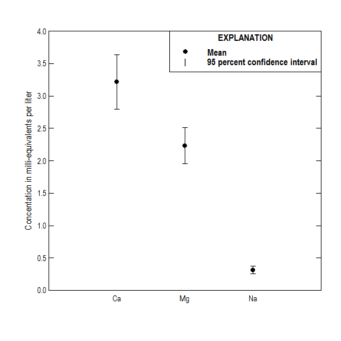

```r
# Set up the graphics environment, the equivalent call for an on screen
#  device could be setPage("square")
setPNG()
# Construct means and 95 percent confidence intervals for selected constituents
# in the IonBalance dataset (smwrData)
Stats <- lapply(IonBalance[, c("Ca", "Mg", "Na")],
  function(x) {
    stats <- t.test(x)
    return(c(mean=as.vector(stats$estimate),
      U95=stats$conf.int[2], L95=stats$conf.int[1]))
  })
Stats <- as.data.frame(do.call(rbind, Stats))
Stats$Constituent <- as.factor(row.names(Stats))
# Now the plot and add error bars
AA.pl <- with(Stats, xyPlot(Constituent, mean, yaxis.range=c(0,4),
  Plot=list(name="Mean"),
  ytitle="Concentation in milli-equivalents per liter"))
AA.pl <- with(Stats, addErrorBars(Constituent, L95, U95,
    Bars=list(name="95 percent confidence interval"), current=AA.pl))
# And the explanation
addExplanation(AA.pl, "ur")
```

Figure 1: A graph with error bars.

# Biplot

The scaling between observations and variables is controlled by the `Scale` argument, which can take any value between 0 and 1 or a character string indicating a specific scaling. The options for the character string are “distance,” which produces a plot where the observations retain their approximate relation with respect to Eucldiean distances and correponds to a numeric value of 1; “variance,” which produces a plot where the cosine of the angle between the variable vectors is related to the correlation between the variables and corresponds to a numeric value of 0; “symmetric,” which tries to balance the range of values for observations and variables to give a pleasing graph and corresponds to a numeric value of 0.5; or “Auto,” which is the same as “variance.” This scaling scheme echoes the presentation in Gower and Hand (1996).

```r
setPNG()
# Construct the PCA from calcium, magnesium, and sodium and print it
MGW.pp <- princomp(data.matrix(MiscGW[, c("Calcium", "Magnesium", "Sodium")]),
  cor=TRUE, scores=TRUE)
print(MGW.pp)
```

```
## Call:
## princomp(x = data.matrix(MiscGW[, c("Calcium", "Magnesium", "Sodium")]),
##     cor = TRUE, scores = TRUE)
##
## Standard deviations:
##    Comp.1    Comp.2    Comp.3
## 1.5562434 0.6042572 0.4614971
##
##  3  variables and  4 observations.
```

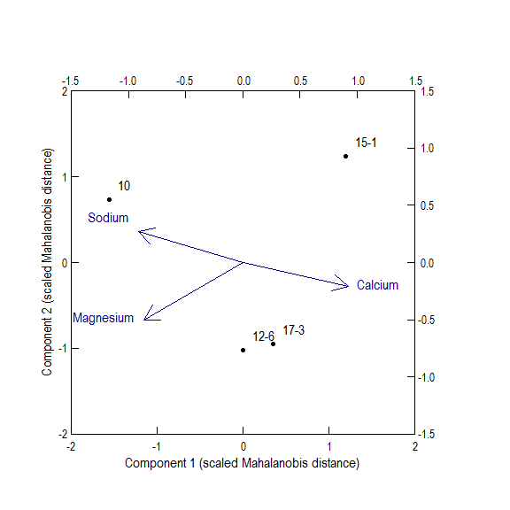

```r
# Create the biplot using the default settings
biPlot(MGW.pp)
```

Figure 2: A biplot from a principal component analysis.

# Scaleless Graph

Scales on ordination graphs are relative to the data shown and have no absolute value. When general relations between parameters are shown without the use of a grid or scale, arrows must be added to show general direction of increasing amount. The actual value of the scale from a principal component analysis or non-metric multidimensional scaling are relative to the data and can be shown with an arrow indicating the general increasing value.

This example shows a scaleless graph from the previous principal component analysis and illustrates the use of `addStiff` to show the actual ionic strengths.

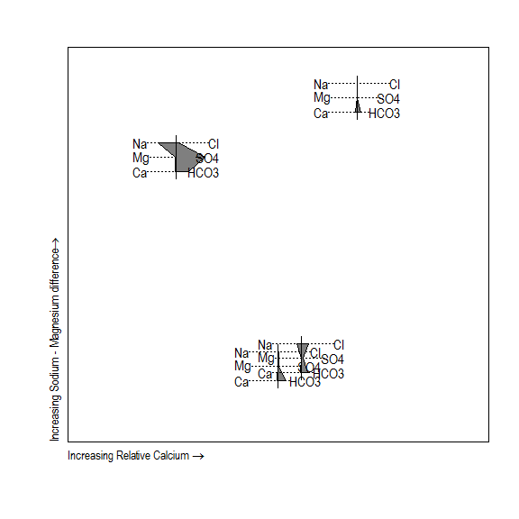

```r
setPNG()
# Use the PCA from the previous example. The scores component provides the
# coordinate information for each observation.
# From the biplot, the first axis repesent increasing calcium and the second
# axis increasing difference between sodium and magnesium.
#
# First set up the graph
AA.pl <- with(MGW.pp, xyPlot(scores[,1], scores[,2], Plot=list(what="none"),
  ylabels=0, xlabels=0, ytitle="", xtitle=""))
# Add the axis Labels, these can be placed at the axis minimum, given by
# the "usr" parameter.
addLabel(expression("Increasing Relative Calcium" %->% ""), par("usr")[1],
  "bottom", justification="left", current=AA.pl)
addLabel(expression("Increasing Sodium - Magnesium difference" %->% ""),
  par("usr")[3],
  "left", justification="left", current=AA.pl)
# Add the Stiff diagrams
AA.pl <- with(MiscGW, addStiff(MGW.pp$scores[,1], MGW.pp$scores[,2],
  width=1, height=0.5, cations=cbind(Calcium, Magnesium, Sodium),
  anions=cbind(Bicarbonate, Sulfate, Chloride),
  catlabels=c("Ca", "Mg", "Na"), anlabels=c("HCO3", "SO4", "Cl"),
  current=AA.pl))
```

```r
# Note that there will be overlapping of the Stiff diagram
```

Figure 3: A scaleless graph also showing Stiff diagrams.

# Area Graph

This example shows a simple area graph that shows the area under a log-Pearson type III density curve. The function `dlpearsonIII` is in the `smwrBase` package that is automatically loaded by when the `smwrGraphs` package is loaded.

The `areaPlot` function only works with numeric x-coordinate data. See the demo `durationHydrograph.r` to see an example using date/time x-coordinate data.

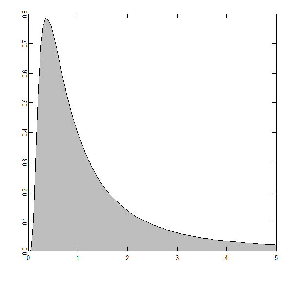

```r
# First generate the sequence of x-coordinate values
Xdata <- seq(0, 5, length.out=101)
# Draw the curve
areaPlot(Xdata, dlpearsonIII(Xdata, 0, 1, .5), Areas=list(fillDir="under",
  fillColors="gray"), xaxis.range=c(0,5))
```

Figure 4: An example area graph.

# Contour Plot

The `contourPlot` function can draw contour lines or filled contours from either x, y, and z data or from a matrix with x and y grid locations. The example in this section creates a filled contour graph of soil-temperature data from data collected at known depths at regular intervals, but uses the methods for arbitrary x, y, and z data.

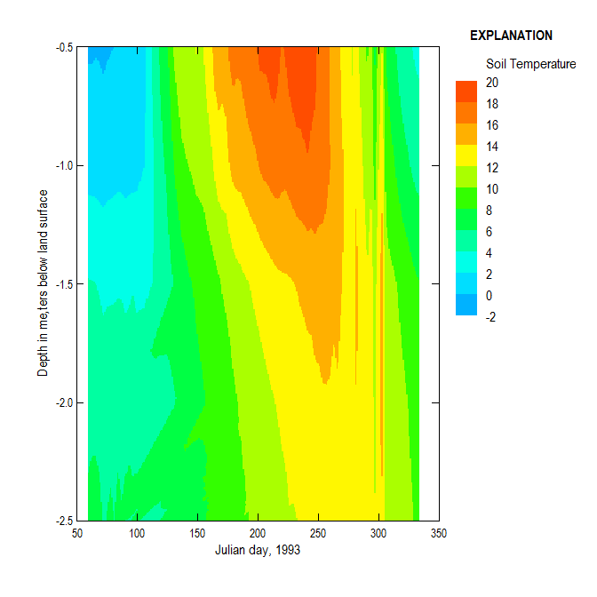

```r
setPNG()
# First set up the data in proper form--separate columns for the x- (JULIAN),
# y-(Depth), and z-axis (Temperature) data.
# setPNG("test", width=6, height = 6)
MC11_stack <- reshape(MC11_1993[, c(2, 6:10)], direction="long", varying=list(2:6),
  timevar="Depth", times=c(0.5, 1.0, 1.5, 2.0, 2.5), v.names="Temperature")
# Set up for an explanation
AA.lo <- setLayout(explanation=list(right=1.5))
# Create the contour plot, Note that z is the first argument and no option for
# reversing the sense of the y axis!
setGraph(1, AA.lo)
AA.pl <- with(MC11_stack, contourPlot(Temperature,JULIAN, -Depth,
  Contours=list(name="Soil Temperature", filled=TRUE),
  xaxis.range=c(50, 350), ytitle="Depth in me,ters below land surface",
  xtitle="Julian day, 1993"))
# Add the explanation
setGraph("explanation", AA.lo)
addExplanation(AA.pl)
```

```r
# graphics.off()
```

Figure 5: A contour plot with filled contours.

# Correlogram

The `corGram` function is used primarily as a diagnostic plot for regressions on irregularly spaced samples. The term correlogram can also be used in time-series analysis, where the observations are regularly spaced and in spatial analysis to display spatial correlation.

This example shows 5 conditions typically shown in regression diagnostics: no correlations structure, serial correlation, seasonal or temporal lack of fit, and time-series anomalies. It uses randomly generated data to display the conditions. Each of the y values for the conditions will be scaled to a mean of 0 and standard deviation of 1 because the y values are not centered by `corGram`.

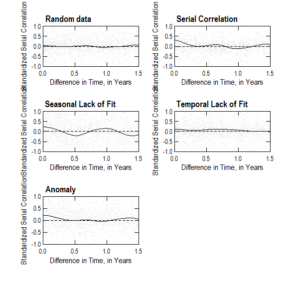

```r
# Generate the random data.
set.seed(1236)
# Use sorted observations in decimal format for 4 years of data collection
Rdates <- sort(runif(100, 2010, 2014))
# The random, no serial correlation data
Yrand <- scale(rnorm(100))
# Add serial correlation
Yser <- scale(Yrand + c(0, Yrand[-100]) + c(0, 0, Yrand[-c(99,100)])/3)
# Seasonal and temporal lack of fit
Yseas <- scale(Yrand + cos(2*pi*Rdates))
Ytime <- scale(Yrand + seq(-1, 1, length.out=100))
# And the anomaly
Yanom <- scale(Yrand + 0.75*(Rdates > 2011.1 & Rdates < 2011.7))
# Set up for the graphs and create the correlograms
# These use gray90 color and reset the yaxis range to emphasize the line
setPNG()
AA.lo <- setLayout(num.rows=3, num.cols=2)
setGraph(1, AA.lo)
corGram(Rdates, Yrand, Plot=list(color="gray90"), yaxis.range = c(-1, 1))
addTitle("Random data")
setGraph(2, AA.lo)
corGram(Rdates, Yser, Plot=list(color="gray90"), yaxis.range = c(-1, 1))
addTitle("Serial Correlation")
setGraph(3, AA.lo)
corGram(Rdates, Yseas, Plot=list(color="gray90"), yaxis.range = c(-1, 1))
addTitle("Seasonal Lack of Fit")
setGraph(4, AA.lo)
corGram(Rdates, Ytime, Plot=list(color="gray90"), yaxis.range = c(-1, 1))
addTitle("Temporal Lack of Fit")
setGraph(5, AA.lo)
corGram(Rdates, Yanom, Plot=list(color="gray90"), yaxis.range = c(-1, 1))
addTitle("Anomaly")
```

Figure 6: Selected correlograms.

The smooth line correlogram for random, uncorrelated data shows only small and irregular flucations around the zero line, much like the example. Serial correlation is indicated when the smooth line is substantially greater than zero at a time difference of zero years, gradually approaches zero and then flutuates around the zero line; the fluctuation in the example are a bit larger than expected. A seasonal lack of fit is inidicated by a smooth line that shows a distinct periodic pattern—a single period is indicated in the example, above zero at a difference in 0 and 1 year and less than zero at a difference of 0.5 year; a double period show a line above 0 at 0, .5, and 1 year difference in time and less than zero at 0.25 and 0.75 year difference; and so forth. A lack of fit over time is indicated by a smooth line that persists above zero for a time difference greaer than about 0.5 year, much as indicated in the example graph. The anomaly is more difficult to diagnose; it can show characteristics of the smoothed serial and seasonal correlogram lines. It is distincly different from the seasonl smooth line in that there is no peak at a time difference of 1 year. The example shows a curve that is not substantially different from one showing serial correlation, but shows no peak near a time difference of 1 year.

# Surface Plot

A surface plot is a three dimensional presentation of a surface in contrast to a contour plot that uses either lines or colors to indicate the surface. There are two steps to displaying a surface plot using the functions in `smwrGraphs`: the first step is to set the projection for the surface plot using `preSurface`, the second step is to draw the surface using `surfacePlot}. This exmaple sets up a simple surface plot of the MC11 data used in the contour plot example.

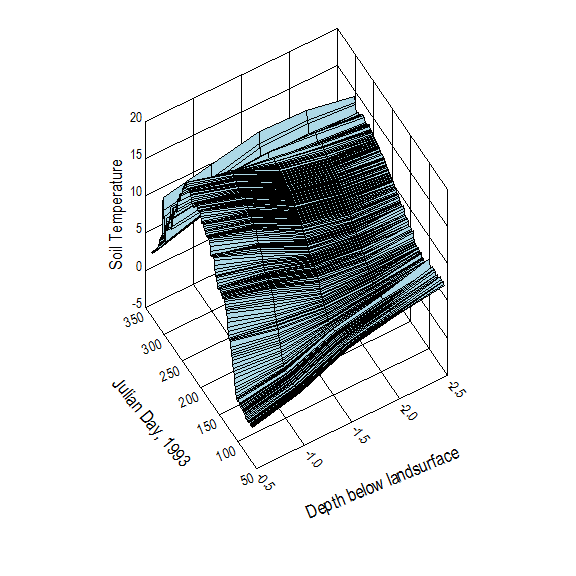

```r
setPNG()
# First set up the projection. The preSurface function can be interactive,
# This script sets the projection to A and supresses the request for user input.
AA.pre <- with(MC11_1993, preSurface(JULIAN, c(-2.5, -2.0, -1.5, -1.0, -0.5),
  cbind(TEMP.2.5, TEMP.2.0, TEMP.1.5, TEMP.1.0, TEMP.0.5), batch="A"))

surfacePlot(AA.pre, xtitle="Julian Day, 1993", ytitle="Depth below landsurface",
  ztitle="Soil Temperature")
```

Figure 7: A surface plot.

# A Report Graph

A report graph is simply formatted text written to a graphics device. The intent is generally to produce some kind of documentation for a statistical analysis. Oftentimes following pages will contain diagnostic or other graphs from the analysis. The function `reportGraph} will try to put the printed output from any R object onto a graph page. It does not check to verify that the width or length will fit in the graph area; any text that is to the right or below the text that can be seen is simply not shown. The example in this section simply shows the summary report from a simple linear regression.

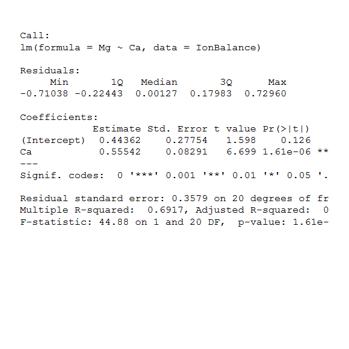

```r
# Construct the regression
AA.lm <- lm(Mg ~ Ca, data=IonBalance)
# And write the report
setPNG()
reportGraph(summary(AA.lm))
```

Figure 8: A graph showing the report from a simple linear regression.

# A Dendrogram

A dendrogram presents the results of a hierarchical cluster analysis in graphical form. This example will perform a cluster analysis of the the Calcium and Magnesuim data in the IonBalance dataset. The exmaple dendrogram suggests two clusters: smaples taken in the fall and winer and smaples taken in the spring and summer.

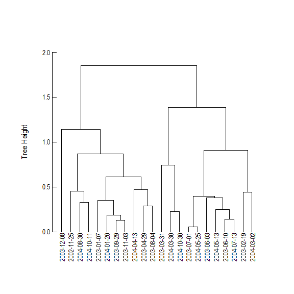

```r
setPNG()
# Extract the data and assigne rownames based on sample date
CaMg <- data.matrix(IonBalance[, c("Ca", "Mg")])
rownames(CaMg) <- as.character(IonBalance$DATES)
# Construct the distance matrix and the cluster analysis
CaMg.dist <- dist(CaMg)
CaMg.hclust <- hclust(CaMg.dist, method="average")
# Dreaw the dendrogram
dendGram(CaMg.hclust, ytitle="Tree Height")
```

Figure 9: The dendrogram of the example cluster analysis.

# Bibliography

Gower, J.C. and Hand, D.J., 1996, Biplots, Chapman and Hall, London, 277 p.